# Replication of the Online Visual Crowding Experiment Using the Virtual Chinrest by Li et al.(2020, Scientific Reports)

Wanjing Anya Ma wanjingm@stanford.edu

November 23, 2021

## Introduction

Online experiments enable psychophysical researchers to study larger and more diverse participant samples than they could have in the laboratory but leave challenges in controlling participants’ viewing distance and the presentation of visual stimuli. The Virtual Chinrest, introduced and validated in Li et al. (2020), was designed to tackle these challenges by an estimation of the viewing distance through measuring the participant’s blind spot location. The authors included two main parts: (1) two validation experiments of the Virtual Chinrest in the lab with participants being instructed to sit at varying viewing distances, and (2) a successful online replication of a lab-based study on visual crowding using the Virtual Chinrest.

### Justification for choice of study

I chose to replicate this study for three reasons. (1) As a new student of psychophysical research, I am interested in learning a whole validation pipeline from a simple controlled lab environment to an uncontrolled online experiment. Due to the time constraint, I will replicate the uncontrolled online experiment (Study 4) only. (2) Replicating this study will enhance my technical skills in using jsPsych and Javascript. (3) More importantly, the second part of the study involved implementing an adaptive algorithm to present stimuli, which matches my research interest.

### Anticipated challenges

The major challenge I anticipate is the time constraint. Implementing an adaptive visual crowding experiment might be time-consuming if the original source code is not available. In addition, compared with the original online study that was available online for 15 months to collect data, I will not be able to replicate the whole findings in the last experiment (e.g., the difference in the viewing distance between people with and without dyslexia).

### Links

Project repository (on Github): [AnyaWMa] https://github.com/psych251/li2020.git

Original paper (as hosted in your repo): https://github.com/psych251/li2020/blob/main/original_paper/Li_et_al-2020-Scientific_Reports.pdf

## Methods

### Power Analysis

[NEED ATTENTION] I am not sure how to interpret the effect size of the original paper. What is the weight?

```r
library(esc)

esc_mean_se(grp1m = 1.623,   # mean of group 1
            grp1se = 0.592,  # standard error of group 1
            grp1n = 742,    # sample in group 1
            grp2m = 2.584,    # mean of group 2
            grp2se = 1.162,  # standard error of group 2
            grp2n = 280,    # sainmple in group 2
            es.type = "d") # convert to SMD; use "g" for Hedges' g
```

```
##
## Effect Size Calculation for Meta Analysis
##
##      Conversion: mean and se to effect size d
##     Effect Size:  -0.0563
##  Standard Error:   0.0701
##        Variance:   0.0049
##        Lower CI:  -0.1938
##        Upper CI:   0.0812
##          Weight: 203.2237
```

```r
library(MKpower)
```

```r
## two-sample
power.welch.t.test(delta = 0.961, sd1 = 0.592, sd2 = 1.163, power = 0.8)
```

```
##
##      Two-sample Welch t test power calculation
##
##               n = 15.8446
##           delta = 0.961
##             sd1 = 0.592
##             sd2 = 1.163
##       sig.level = 0.05
##           power = 0.8
##     alternative = two.sided
##
## NOTE: n is number in *each* group
```

### Planned Sample

In order to meet 80% power, I planned to have 16 participants for each condition, so there will be 32 participants in total. Only neurotypical, young adults (age range: 18-30) will be recruited in this replication study.

### Experimental Design

> “The online experiment was launched on the volunteer-based online experiment platform LabintheWild and advertised with the slogan “How accurate is your peripheral vision?” on the site itself as well as on social media. Experimental design. During each experimental session, we first presented the Virtual Chinrest experiment and used the results to calculate individual’s viewing distance and to calibrate the stimuli’s size and locations. Instead of creating stimuli (demonstrated in Fig. 5) using MATLAB, we created the stimuli as SVG on HTMLs and manipulated the stimuli using JavaScript. All the elements were created in a container with a width of 900 pixels on the webpage. In the blind spot test, the dot was drawn in red with a diameter of 30 pixels, and the fixation square was drawn in black with a side length of 30 pixels (Fig. 1b). Replicating the original crowding study30 in the unit of visual degrees, stimuli comprised four flankers — open circles with 1° diameter and a target — an open circle with a gap (target; an arc with reflex central angle of 330°). All stimuli were black and displayed on a white background (Fig. 5). Two conditions of target eccentricity (the center-to-center distance between the fixation mark at the center of the webpage and the target) were 4° and 6°. In each crowding experiment session, each participant was randomly assigned one target eccentricity, and the target eccentricity was fixed with the starting target-flanker distance being set as 1.3 times greater than half the eccentricity (3.9° for 6° eccentricity; 2.6° for 4° eccentricity). During each crowding experiment session, the subsequent target-flanker distances (25 trials/steps in total) were controlled by the 1-up 3-down staircase procedure implemented in JavaScript [https://github.com/hadrienj/StaircaseJS]. On a given trial, the fixation mark was displayed first and remained on the webpage for the entire session. After 500 ms of fixation onset, the stimuli were displayed either to the left or the right of the fixation for 150 ms. Only the fixation remained on the webpage until the participant submitted a response by using the arrow keys on the keyboard to indicate the direction (up or down) of the target gap. No feedback was provided during the experiment. There was a 500 ms blank between a participant’s response and the beginning of the next trial. The visual crowding, defined as the minimal center-to-center distance between a target and the flankers (in degrees), was used to quantify the crowding effects when participants could report the target identity at certain accuracy. Since we are using a 1-up 3-down staircase procedure, participants should be able to correctly report the target identity 79.4% of times."

### Procedure

> “The experiment began with a brief overview of the study, an informed consent form approved by the University of Washington Institutional Review Board, and a voluntary demographic questionnaire, followed by the card task and the blind spot test with 5 trials to calculate participants’ viewing distances. Participants were then presented the instruction of the crowding tasks and a practice session with 5 trials. The main experiment was split into two blocks (two independent staircases, 25 trials each), and each was followed by another blind spot task with 3 trials. After the last blind spot test, participants were then given the opportunity to report on any technical difficulties, and to provide any other general comments or questions. The final page showed their personalized “crowding effect” in comparison to others. The entire study took 10–12 minutes to complete."

### Analysis Plan

> “We deployed the online study in two stages, where we added more granular data log at the second stage, such as the percentage correctness of the experiment and the results of each individual trial. Therefore, the analysis of visual crowding effects (Fig. 7a,b) was performed on the data of 793 participants from the second stage, the results in Table 2 was based on a subset of 570 participants who have explicitly reported whether they have dyslexia and/or other related impairments, while the results of the viewing distances from the three blind (Fig. 7c–e) spot tests were reported from all 1153 participants. We checked for data normality by both the visual inspection of histograms and the Shapiro-Wilk normality tests before each analysis. We then conducted parametric (e.g. the Welch’s two sample t-test) and non-parametric (e.g. Mann-Whitney U test) analysis accordingly. In the linear mixed-effects regression models, t-tests (p-values) were calculated using Satterthwaite approximations for the degrees of freedom. The data analysis of all four experiments was performed in R, with the help of multiple packages.”

### Differences from Original Study

Here are three major differences between this replication study and the original study.

#### Experiment Implementation

The original study implemented the Virtual Chinrest and visual crowding experiment using JavaScript. Only part of the code used jsPsych library. In my replication, I will refer the high level idea of the original source code, but I decide to use the existing Virtual Chinrest jsPsych plugin and build the entire visual crowding experiment through jsPsych. The code, free from the original lab’s coding framework, should be more concise and more accessible for future replication studies.

#### Data Collection

The original study recruited participants on the volunteer-based experiment platform LabintheWild, while this replication project used Prolific, a crowdsourcing platform recruit participants with pay. Using Prolific may lead to higher quality data because participants are paid and it doesn’t need to rely on participants’ self-report whether they have completed the study before.

Data from the original study was written into the first author’s MySQL database. However, I will use Pavlovia to host the experiment and store data directly into my GitLab.

## Methods Addendum

### Pilot A

The Pilot A data includes a total of 6 participants (3 for each eccentricity condition).

1. Virtual Chinrest: two participants reported that the red dot did not go far enough to the left if the participant was too far away from the screen.
2. Instructions: One participants reported that there were a lot of instructions on the peripheral vision task page. She suggested “I would break it up in bullet points or present 1 and 2 on separate pages, reading long lines of instructions is not encouraging.”
3. Practice Trials: One participant said she would have a better idea of the experiment if she could have more practice trials.

To fix the problem 1, I need to check the jsPsych plugin code to adjust the movement of the red dot in the blind spot measurement trial. However, I will not resolve problem 2 and 3 to be faithful to the original study, although they are good suggestions.

## Results

Data preparation following the analysis plan.

I decided to follow the [data analysis using R] (https://github.com/QishengLi/virtual_chinrest/blob/master/analysis/Exp_4_online_experiment_analysis.ipynb) provided by the first author.

#### Load Relevant Libraries and Functions

#### Import data

```r
### Data Preparation
eccen4_myfiles = list.files(path = "../data/pilotA-eccen4" , pattern= "*.csv", full.names=TRUE)
eccen4_df = ldply(eccen4_myfiles, read_csv)
eccen6_myfiles = list.files(path = "../data/pilotA-eccen6" , pattern= "*.csv", full.names=TRUE)
eccen6_df = ldply(eccen6_myfiles, read_csv)
```

#### Data exclusion / filtering

```r
filtered_eccen4_df <-
  eccen4_df  %>%
  drop_na(participantID) %>%
  filter(correctRate > 0.0)
```

```r
filtered_eccen4_df <- subset(filtered_eccen4_df, select= c(participantID, eccentricity_deg, critical_spacing_deg, crowding_session, correctRate))
```

```r
filtered_eccen6_df <-
  eccen6_df  %>%
  drop_na(participantID) %>%
  filter(correctRate > 0.0)
```

```r
filtered_eccen6_df <- subset(filtered_eccen6_df, select= c(participantID, eccentricity_deg, critical_spacing_deg, crowding_session, correctRate))
```

```r
visual_crowding <- rbind(filtered_eccen6_df, filtered_eccen4_df)
```

```r
distance_eccen4_df <-
  eccen4_df  %>%
  filter(grepl("end_trial", trialType))

distance_eccen4_df <- subset(distance_eccen4_df, select= c(participantID,viewDistance_1, viewDistance_2, viewDistance_3 ))

distance_eccen6_df <-
  eccen6_df  %>%
  filter(grepl("end_trial", trialType))

distance_eccen6_df <- subset(distance_eccen6_df, select= c(participantID,viewDistance_1, viewDistance_2, viewDistance_3 ))

viewing_distance_df<- rbind(distance_eccen4_df,distance_eccen6_df)
viewing_distance_df
```

| participantID | viewDistance_1 | viewDistance_2 | viewDistance_3 |
| --- | --- | --- | --- |
| A47meOKIDYgLnxpl | 47.924 | 45.857 | 47.075 |
| 5f3xSjoiUwaWdW1k | 55.262 | 60.779 | 60.593 |
| 8GYhNwJamJ1CrFlS | 69.014 | 69.015 | 61.123 |
| VmiyXDDM7SJW0dzN | 54.503 | 55.163 | 51.502 |
| UHB3ugGTmB1Cnwlb | 41.688 | 45.514 | 45.721 |
| Vvl0QWLyd96zclSX | 60.047 | 56.840 | 56.806 |

```r
viewing_distance_reshape_df <- reshape(data= viewing_distance_df, idvar="participantID",
                         varying = c("viewDistance_1", "viewDistance_2", "viewDistance_3"),
                         v.name=c("viewDistance"),direction="long", times = c(1,2,3))


viewing_distance_reshape_df
```

|  | participantID | time | viewDistance |
| --- | --- | --- | --- |
| A47meOKIDYgLnxpl.1 | A47meOKIDYgLnxpl | 1 | 47.924 |
| 5f3xSjoiUwaWdW1k.1 | 5f3xSjoiUwaWdW1k | 1 | 55.262 |
| 8GYhNwJamJ1CrFlS.1 | 8GYhNwJamJ1CrFlS | 1 | 69.014 |
| VmiyXDDM7SJW0dzN.1 | VmiyXDDM7SJW0dzN | 1 | 54.503 |
| UHB3ugGTmB1Cnwlb.1 | UHB3ugGTmB1Cnwlb | 1 | 41.688 |
| Vvl0QWLyd96zclSX.1 | Vvl0QWLyd96zclSX | 1 | 60.047 |
| A47meOKIDYgLnxpl.2 | A47meOKIDYgLnxpl | 2 | 45.857 |
| 5f3xSjoiUwaWdW1k.2 | 5f3xSjoiUwaWdW1k | 2 | 60.779 |
| 8GYhNwJamJ1CrFlS.2 | 8GYhNwJamJ1CrFlS | 2 | 69.015 |
| VmiyXDDM7SJW0dzN.2 | VmiyXDDM7SJW0dzN | 2 | 55.163 |
| UHB3ugGTmB1Cnwlb.2 | UHB3ugGTmB1Cnwlb | 2 | 45.514 |
| Vvl0QWLyd96zclSX.2 | Vvl0QWLyd96zclSX | 2 | 56.840 |
| A47meOKIDYgLnxpl.3 | A47meOKIDYgLnxpl | 3 | 47.075 |
| 5f3xSjoiUwaWdW1k.3 | 5f3xSjoiUwaWdW1k | 3 | 60.593 |
| 8GYhNwJamJ1CrFlS.3 | 8GYhNwJamJ1CrFlS | 3 | 61.123 |
| VmiyXDDM7SJW0dzN.3 | VmiyXDDM7SJW0dzN | 3 | 51.502 |
| UHB3ugGTmB1Cnwlb.3 | UHB3ugGTmB1Cnwlb | 3 | 45.721 |
| Vvl0QWLyd96zclSX.3 | Vvl0QWLyd96zclSX | 3 | 56.806 |

### Visual Crowding Statistics

```r
#Mean, SD, Standard error of the mean (sem)
visual_crowding_by <- visual_crowding %>%
  dplyr::group_by(eccentricity_deg) %>%
  dplyr::summarise(mean = mean(critical_spacing_deg),sd = sd(critical_spacing_deg), sem = sd(critical_spacing_deg)/sqrt(length(critical_spacing_deg)))

#wilcoxon rank sum test
wilcox.test(critical_spacing_deg~eccentricity_deg,data=visual_crowding)
```

```
##
##  Wilcoxon rank sum test with continuity correction
##
## data:  critical_spacing_deg by eccentricity_deg
## W = 9, p-value = 0.1689
## alternative hypothesis: true location shift is not equal to 0
```

#### Reproduce Figure 7a:

```r
cr_bars <- aggregate(critical_spacing_deg~eccentricity_deg, data = visual_crowding, mean)
cr_stderr <- visual_crowding %>%
  dplyr::group_by(eccentricity_deg) %>%
  dplyr::summarise(sem = sd(critical_spacing_deg)/sqrt(length(critical_spacing_deg)))
cr_bars <- merge(cr_bars, cr_stderr, by=c('eccentricity_deg'))
```

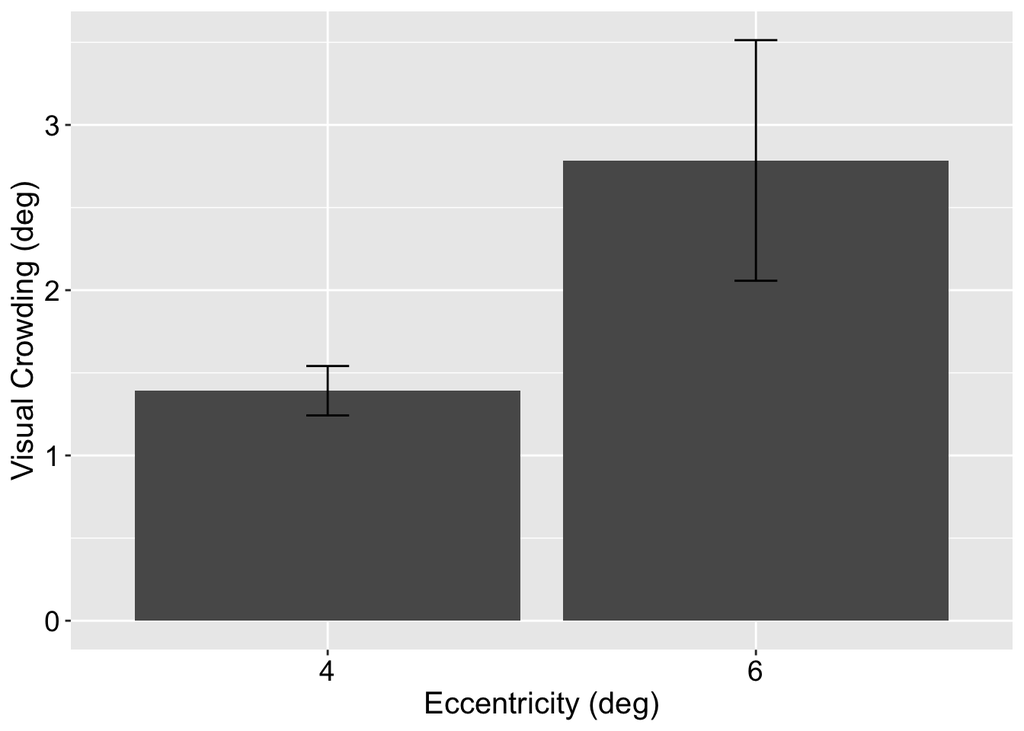

```r
ggplot(data=cr_bars, aes(x=as.factor(eccentricity_deg), y=critical_spacing_deg)) +
  geom_bar(stat="identity", position=position_dodge())  +
  geom_errorbar(aes(ymin=critical_spacing_deg-sem, ymax=critical_spacing_deg+sem), width=.1, position=position_dodge()) +
  labs(x = "Eccentricity (deg)", y = "Visual Crowding (deg)") +
  theme(axis.text=element_text(size=14, color='black'), axis.title=element_text(size=15), legend.text=element_text(size=10))
```

#### Reproduce Figure 7b:

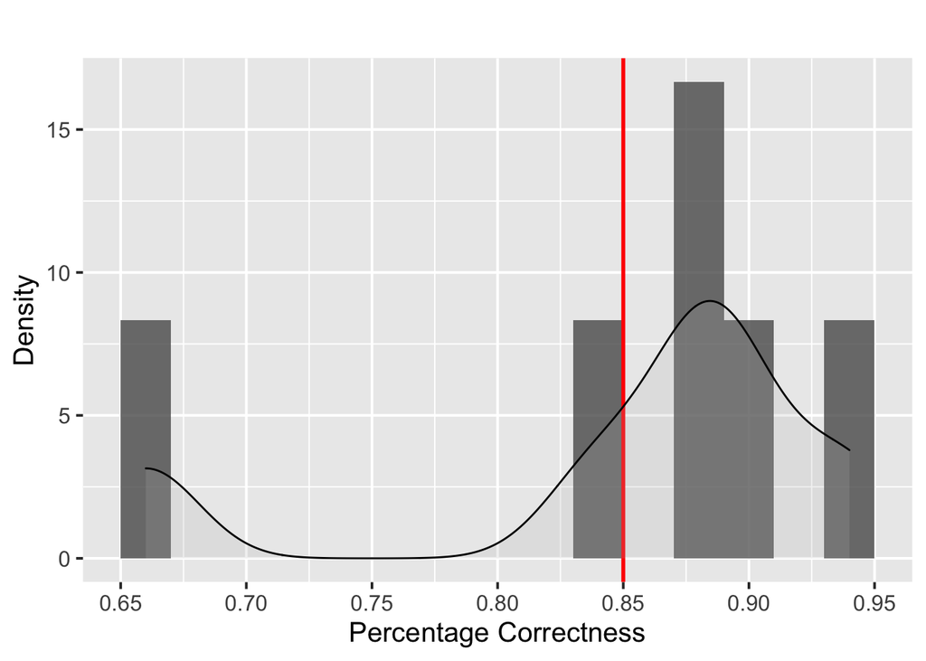

```r
visual_crowding_accuracy <- aggregate(correctRate~participantID, data = visual_crowding, mean)

#histgram of participant accuracy
ggplot(visual_crowding_accuracy, aes(x=correctRate)) + geom_histogram(aes(y=..density..), binwidth = 0.02, alpha=.8) +
  geom_vline(aes(xintercept=mean(correctRate)), color="red", size=1) +
  geom_density(alpha=.2, fill="grey") +
  scale_x_continuous(breaks = scales::pretty_breaks(n = 5)) +
  labs(title="", x="Percentage Correctness", y="Density") +
  theme_grey(base_size = 15)
```

```r
#summary: mean, min, max
summary(visual_crowding_accuracy$correctRate)
```

| Min. | 1st Qu. | Median | Mean | 3rd Qu. | Max. |
| --- | --- | --- | --- | --- | --- |
| 0.66 | 0.85 | 0.88 | 0.85 | 0.895 | 0.94 |